# An Easy Way To Fine-Tune Stable Diffusion with Dreambooth (Colab)

In their awesome paper "**[DreamBooth: Fine-tuning Text-to-Image Diffusion Models for Subject-Driven Generation](https://dreambooth.github.io/)**", introduced at *CVPR (Conference on Computer Vision and Pattern Recognition) 2023* its authors *Ruiz N*, *Li Y*, *Jampani V*, *Pritch Y*, *Rubinstein M*, and *Aberman K* present a novel approach to enhancing text-to-image models through personalized fine-tuning.

It fine-tunes a pretrained model with a small set of subject-specific images, enabling it to associate a **unique identifier** with the subject. This allows the model to generate novel, photorealistic images of the subject in diverse contexts and conditions, leveraging **semantic priors** and a **specialized preservation loss**.

**Benefits**:

1. **Personalization**: Tailors image generation to specific subjects based on a few reference images.
2. **Versatility**: Enables synthesis of images in various scenes, poses, views, and lighting conditions not present in the reference set.
3. **Realism**: Produces photorealistic outputs that preserve key features of the subject.
4. **Applications**: Facilitates subject recontextualization, text-guided view synthesis, appearance modification, and artistic rendering.

## Before We Begin

This tutorial helps you train with limited GPU vRAM, like Colab, free 15GB GPU tier or on a local machine.

This code borrows heavily from huggingface diffusers documentation.

## Step 1: Cloning & Installing Packages

```python
# Cloning and installing the Huggingface's official dreambooth diffusers implementation
!git clone https://github.com/huggingface/diffusers
%cd diffusers
!pip install .
%cd ..
# Install the required dependencies for the script
!pip install -U -r diffusers/examples/dreambooth/requirements.txt
# bitsandbytes 8-bit optimizer for training on 15GB GPU
!pip install bitsandbytes
# Accelerate helps you train on multiple GPUs or with mixed-precision.
!pip install accelerate
# Setup a default Accelerate environment
!accelerate config default
```

## Step 2: Directory Setup & Getting Images for Fine Tune

**Dataset** - You can either upload a dataset of images to fine tune the model in the current colab runtime or mount the drive to access a dataset directory present on your drive. (For this tutorial we will just upload it to the current runtime.)

```python
import os
INSTANCE_DIR = "/content/dreambooth/instance_dir"
CLASS_DIR = "/content/dreambooth/class_dir"
WEIGHTS_DIR = "/content/dreambooth/weights_dir"
os.makedirs(INSTANCE_DIR, exist_ok=True)
os.makedirs(CLASS_DIR, exist_ok=True)
os.makedirs(WEIGHTS_DIR, exist_ok=True)
```

```python
# Get five rc_car images from dreambooth's official Github
!wget -P $INSTANCE_DIR https://raw.githubusercontent.com/google/dreambooth/main/dataset/rc_car/00.jpg
!wget -P $INSTANCE_DIR https://raw.githubusercontent.com/google/dreambooth/main/dataset/rc_car/01.jpg
!wget -P $INSTANCE_DIR https://raw.githubusercontent.com/google/dreambooth/main/dataset/rc_car/02.jpg
!wget -P $INSTANCE_DIR https://raw.githubusercontent.com/google/dreambooth/main/dataset/rc_car/03.jpg
!wget -P $INSTANCE_DIR https://raw.githubusercontent.com/google/dreambooth/main/dataset/rc_car/04.jpg
```

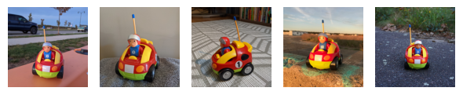

```python
import matplotlib.pyplot as plt
import matplotlib.image as mpimg

def show_images_in_directory(directory):
    fig = plt.figure(figsize=(6, 4))  # Adjust the figure size as needed
    images = [file for file in os.listdir(directory) if file.endswith(('jpg', 'png', 'jpeg'))]  # Filter image files
    num_images = len(images)
    for i, image_name in enumerate(images):
        image_path = os.path.join(directory, image_name)
        img = mpimg.imread(image_path)
        ax = fig.add_subplot(1, num_images, i + 1)
        ax.imshow(img)
        ax.axis('off')
        # ax.set_title(image_name)
    plt.tight_layout()
    plt.show()
show_images_in_directory(INSTANCE_DIR)
```

## Step 3: HuggingFace Hub Token Login

```python
from huggingface_hub import login
# add your huggingface token,
# just create an account at huggingface.com and get a token,
# follow, https://huggingface.co/docs/hub/en/security-tokens
access_token = ""
login(token = access_token)
```

## Step 4: Run the Training

**Tips**:

1. Low learning rate and progressively increasing the number of steps.
- High learning rates and too many training steps will lead to overfitting. The model will mostly generate images from your training data, no matter what prompt is used.
- Low learning rates and too few steps will lead to underfitting: the model will not be able to generate the concept we were trying to incorporate.
- A learning rate of 2e-6 with 400 training steps works well for objects.
2. For faces, 800-1200 steps worked well when using a batch size of 2 and LR of 1e-6.
3. Prior preservation is important to avoid overfitting when training on faces. For other subjects, it doesn't seem to make a huge difference.
4. If images are still noisy run inference for 100 steps.
5. Training the text encoder in addition to the UNet has a big impact on quality. Using techniques like 8-bit Adam, fp16 training or gradient accumulation reduces memory requirements to run on 15 GB GPUs like the ones provided by Google Colab.
6. Try different schedulers during inference process, i.e. **PNDM**, **DDIM**, **LMSDiscrete** etc.

| Parameter | Meaning | Value |
| --- | --- | --- |
| --pretrained_model_name_or_path | Pretrained model to initialize the model from. | "CompVis/stable-diffusion-v1-4" (example) |
| --instance_data_dir | Directory containing instance data. Path to the images directory provided by you for fine tuning the model. | "./dog" (example) |
| --class_data_dir | Directory containing class data. Path to an empty directory provided by you for downloading the generated images for prior preservation loss calculation. | "./class_imgs" (example) |
| --output_dir | Directory to save the trained model weights. | "./model_data" (example) |
| --with_prior_preservation | Flag indicating whether to use prior preservation. Uses a model's own generated samples to help it generate more diverse images. | None |
| --prior_loss_weight | Weight for the prior loss. | 1.0 (recommended) |
| --instance_prompt | Prompt for instance images. | "a photo of sks dog" (example) |
| --class_prompt | Prompt for class images. | "a photo of dog" (example) |
| --resolution | Resolution of images. | 512 (example) |
| --train_batch_size | Batch size for training. | 1 (change according to available vRAM) |
| --gradient_accumulation_steps | Number of gradient accumulation steps. | 1 (recommended) |
| --learning_rate | Learning rate for training. | 1e-6 |
| --lr_scheduler | Learning rate scheduler type. | "constant" |
| --lr_warmup_steps | Number of warmup steps for the learning rate. | 0 |
| --num_class_images | Number of class images to consider. | num_epochs * num_samples 200-300 (recommended) |
| --max_train_steps | Maximum number of training steps. | 800 |
| --checkpointing_steps | Interval for model checkpointing. | 400 |
| --gradient_checkpointing | Flag for gradient checkpointing. | None |
| --use_8bit_adam | Flag for using 8-bit Adam optimizer. | None |
| --mixed_precision | Precision for mixed precision training. | "fp16" / "bf16" |
| --push_to_hub | Flag for pushing trained model to Hub. | None |
| --train_text_encoder | Flag for training the text encoder. Train the text encoder in addition to the UNet. Needs 24GB of vRAM. Produces better results. | None (not recommended for free Colab tier) |
| --snr_gamma | Flag for The Min-SNR weighting strategy. Helps with training by rebalancing the loss to achieve faster convergence. | 5.0 (recommended) |

```python
!accelerate launch /content/diffusers/examples/dreambooth/train_dreambooth.py \
  --pretrained_model_name_or_path="CompVis/stable-diffusion-v1-4"  \
  --instance_data_dir="/content/dreambooth/instance_dir" \
  --output_dir="/content/dreambooth/weights_dir" \
  --instance_prompt="a photo of rc_car car" \
  --resolution=512 \
  --train_batch_size=1 \
  --gradient_accumulation_steps=1 \
  --learning_rate=2e-6 \
  --lr_scheduler="constant" \
  --lr_warmup_steps=0 \
  --max_train_steps=400 \
  --use_8bit_adam \
  --gradient_checkpointing
```

## Final Step: Inference - Generating Images

[figure not shown]

```python
from diffusers import StableDiffusionPipeline
import torch

model_id = "/content/dreambooth/weights_dir"
pipe = StableDiffusionPipeline.from_pretrained(model_id, torch_dtype=torch.float16).to("cuda")

prompt = "A photo of rc_car on a beach"
image = pipe(prompt, num_inference_steps=50, guidance_scale=7.5).images[0]
display(image)
```

## References

- Ruiz N, Li Y, Jampani V, Pritch Y, Rubinstein M, Aberman K (2023) Dreambooth: Fine tuning text-to-image diffusion models for subject-driven generation. In: Proceedings of the IEEE/CVF Conference on Computer Vision and Pattern Recognition
- [Huggingface Dreambooth Blog](https://huggingface.co/blog/dreambooth)
- [Diffusers Documentation](https://huggingface.co/docs/diffusers/index)
- [SuperteamAI Dreambooth Blog](https://www.superteams.ai/blog/steps-to-fine-tune-stable-diffusion-for-image-generation)

Credits: **Yash Kumar Sahu**